# Corridor_level_paper

Huajie Yang

1/31/2020

# 1 Abstract

In the context of increasing daily traffic congestion and auto dependence, light rail transit (LRT) has been suggested as an effective means to reduce auto dependence and relieve traffic congestion. Between 1999 and 2017, nationwide vehicle revenue hours of LRT service has increased from 3.1 million to 7.5 million (NTD, 2000, 2018). There is a growing body of literature investigating the effects of LRT on transit ridership and traffic congestion, but so far previous research has failed to systematically evaluate the short- and long-term effects due to lack of consistent high resolution historical data. Most existing studies have to convert annual average daily traffic as approximate measurements of traffic congestion (Bhattacharjee and Goetz, 2012; Ewing et al., 2014), but such measurements cannot reveal daily or monthly variation in traffic congestion. Emerging high resolution archival transportation data provide a potential opportunity to tackle the problem (Giuliano et al., 2015).

# 2 Introduction

# 3 Data

# 4 Study area and Methodology

Study area section describes the impacted roadways.

## 4.1 Transit ridership

A net increase in transit ridership is a necessary condition for impacts on traffic congestion, thus I conduct four comparisons to examine the impacts on transit ridership within the experimental corridor.

##### 4.1.0.0.1 average weekday boardings

First, this study analyzed average weekday boardings at all bus and rail stops within the experimental and control corridors before and after the operation of the new light rail transit. As shown in Figure 4.1, the vertical dashed line indicates the date when the new light rail transit lines started operation. After the opening of the new light rail transit lines, boardings within the experimental corridor sharply increased while boardings within the control corridor decreased slightly for the Orange Line and almost kept stable for the Green Line.

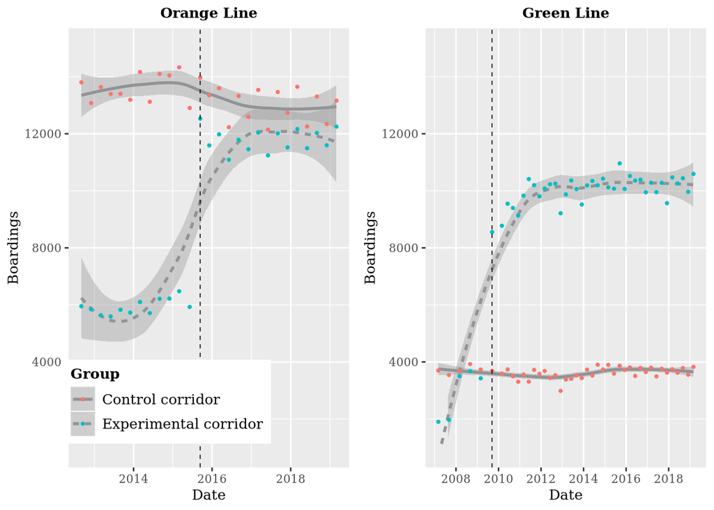

Figure 4.1: Boardings at transit stops within the experimental/control corridors.

###### 4.1.0.0.1.1 DID analysis

```
##
## Ridership DID base and multiple time priods models
## ===============================================================================================================
##                                                                   Dependent variable:
##                                         -----------------------------------------------------------------------
##                                                                        Boardings
##                                            Orage Line        Green Line        Orage Line        Green Line
##                                                (1)               (2)               (3)               (4)
## ---------------------------------------------------------------------------------------------------------------
## Before_after                               -554.000***        -102.000
##                                             (179.000)         (196.000)
##
## GroupExperimental corridor                -7,662.000***      -821.000***      -7,662.000***      -821.000***
##                                             (189.000)         (260.000)         (196.000)         (222.000)
##
## Before_after:GroupExperimental corridor   6,404.000***      7,225.000***
##                                             (254.000)         (277.000)
##
## Year_1st                                                                        -310.000           -44.400
##                                                                                 (278.000)         (256.000)
##
## Year_2nd                                                                       -698.000**         -299.000
##                                                                                 (278.000)         (236.000)
##
## Year_3rd                                                                       -572.000**         -109.000
##                                                                                 (278.000)         (236.000)
##
## Year_4th                                                                       -664.000**         -388.000
##                                                                                 (310.000)         (236.000)
##
## Year_5th                                                                                          -159.000
##                                                                                                   (236.000)
##
## Year_6th                                                                                           66.400
##                                                                                                   (236.000)
##
## Year_7th                                                                                            8.670
##                                                                                                   (236.000)
##
## Year_8th                                                                                           -32.900
```

[output cut: 33 more lines]

```
##                                                                                                   (333.000)
##
## GroupExperimental corridor:Year_10th                                                            7,434.000***
##                                                                                                   (363.000)
##
## Constant                                  13,599.000***     3,716.000***      13,599.000***     3,716.000***
##                                             (134.000)         (184.000)         (139.000)         (157.000)
##
## ---------------------------------------------------------------------------------------------------------------
## Observations                                   54                86                54                86
## R2                                            0.977             0.985             0.978             0.991
## Adjusted R2                                   0.976             0.984             0.974             0.988
## Residual Std. Error                     463.000 (df = 50) 411.000 (df = 82) 481.000 (df = 44) 351.000 (df = 64)
## ===============================================================================================================
## Note:                                                                               *p<0.1; **p<0.05; ***p<0.01
```

Difference-in-Differences effects shown in Figure 4.2

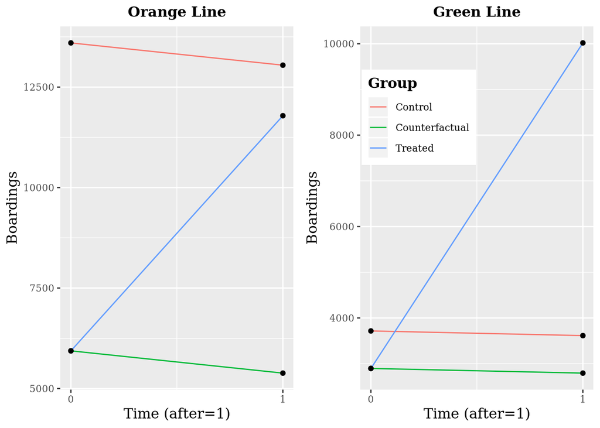

Figure 4.2: Difference-in-Differences effects of boardings

Figure 4.3

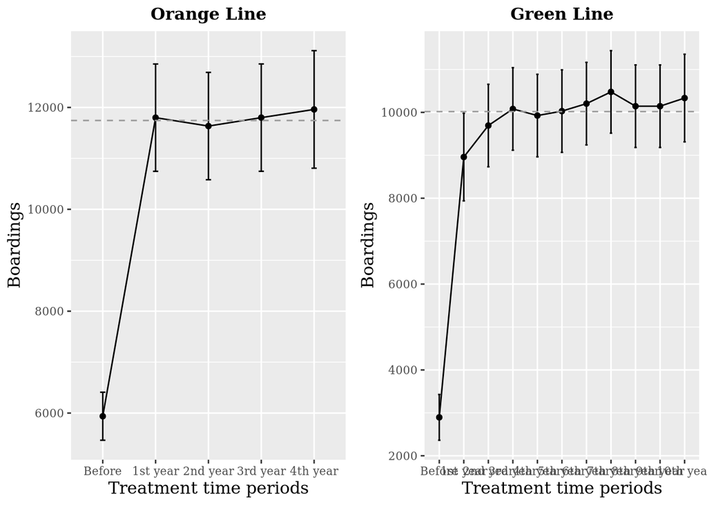

Figure 4.3: Predicted average boardings within the experimental/control corridors.

Then, I divide the ridership within the experimental corridor into new light rail transit and existing transit. Shown in Figure 4.4.The average weekday ridership of Orange line and Green Line exceeded 5000 and 6000 respectively, while the ridership of the existing transit was relative stable after the operation of the new light rail transit lines. Most of the increase in ridership is from the new light rail transit, indicating that the new light rail transit has contributed to the increased transit ridership.

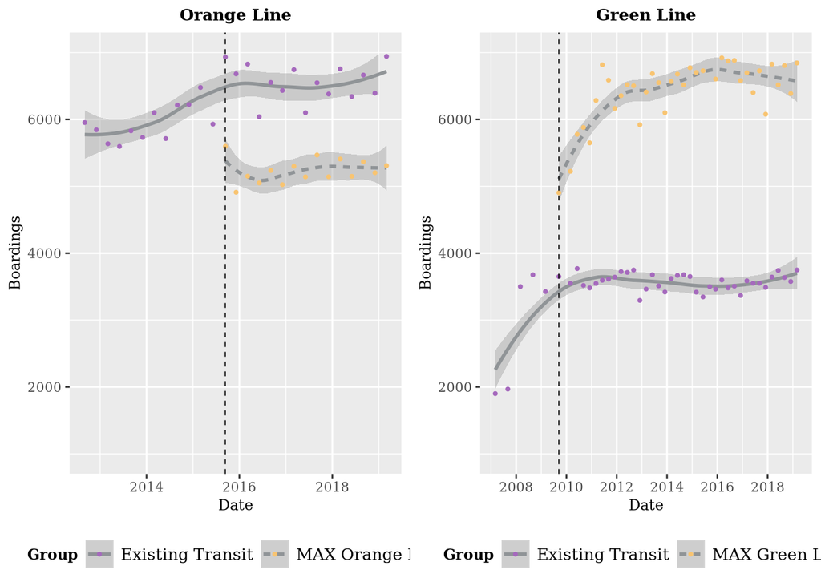

Figure 4.4: Boardings at MAX Orange Line and exisitng transit stops within experimental corridor

##### 4.1.0.0.3 Ridership of traverse bus lines during peak periods

Only drivers switching from driving to transit during peak periods can relieve traffic congestion, I analyzed the weekday peak-period bidirectional ridership of the Orange Line and existing bus lines that traverse the same screenline. Shown in the Figure 4.5, ridership of the existing parallel bus lines decreased slightly while the ridership of the Orange Line is much larger than the decreased ridership of the existing parallel bus lines. The combined effect shows that there is an overall increase in transit ridership within the experimental corridor.

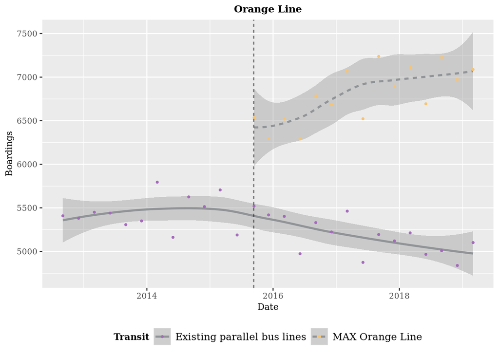

Figure 4.5: Peak periods bidirectional boardings of MAX Orange Line and traverse bus lines

##### 4.1.0.0.4 Boardings and alightings at specific bus stops within a quarter-mile network distance of MAX Orange Line stations.

Lastly, I compared boardings and alightings at bus stops that are within a quarter-mile network distance of Orange Line stops before and after the operation of the Orange Line. Shown in the Figure 4.6, boardings and alightings both largely increased after the operation of the new light rail transit lines. Due to the limitation of data, it is hard to figure out whether such increases result from new ridership or a switch from the existing riderhship.

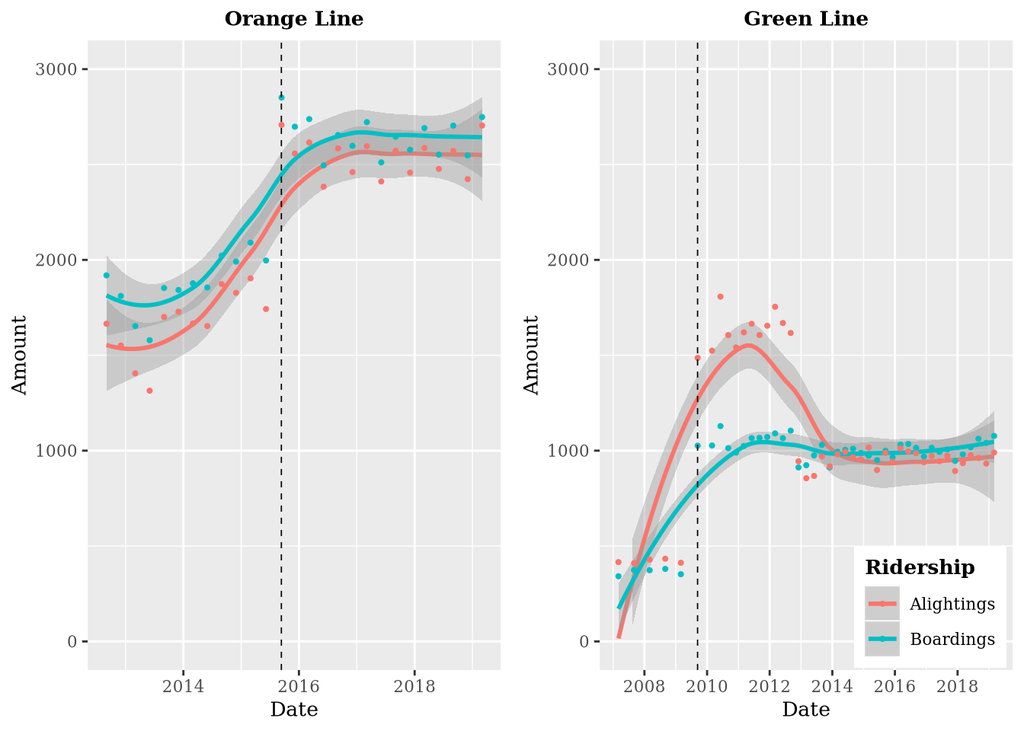

Figure 4.6: Boardings at specific bus stops within a quarter-mile walking radius of new light rail transit stations

## 4.2 Traffic congestion

This study focuses on the impacts on traffic congestion and thus I only examine the changes in travel speed during weekday AM and PM peak periods. The peak periods are consistent with Portland metropolitan area Travel Demand Modeling. The AM peak is 7 to 10 AM, and the PM peak is 4 to 7 PM.

### 4.2.1 Plot

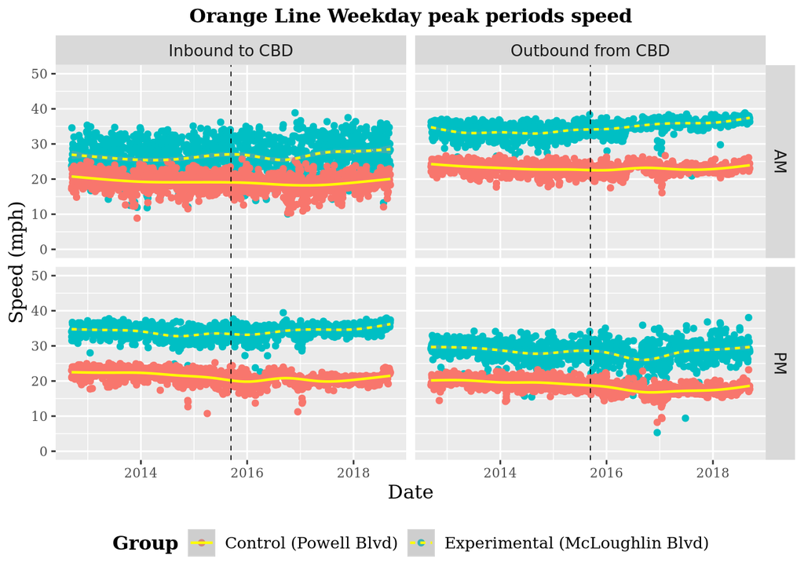

Figure 4.7: Orange Line Weekday peak periods speed

Figure 4.8

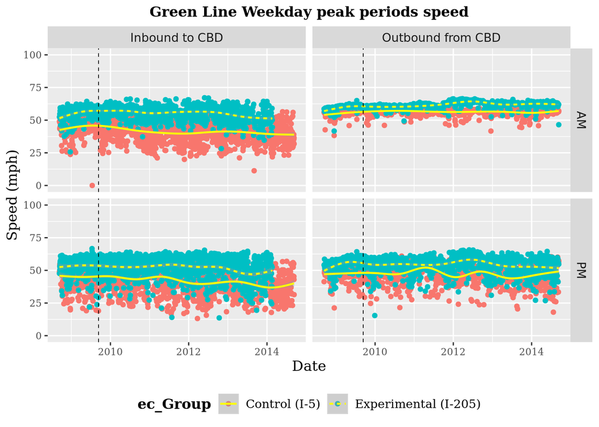

Figure 4.8: Green Line Weekday peak periods speed

### 4.2.2 T-test

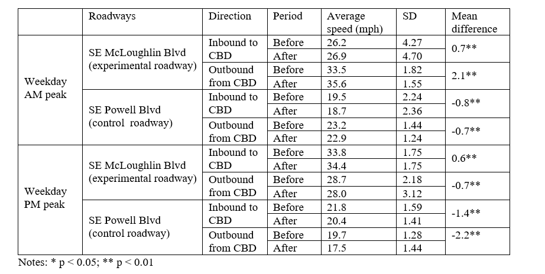

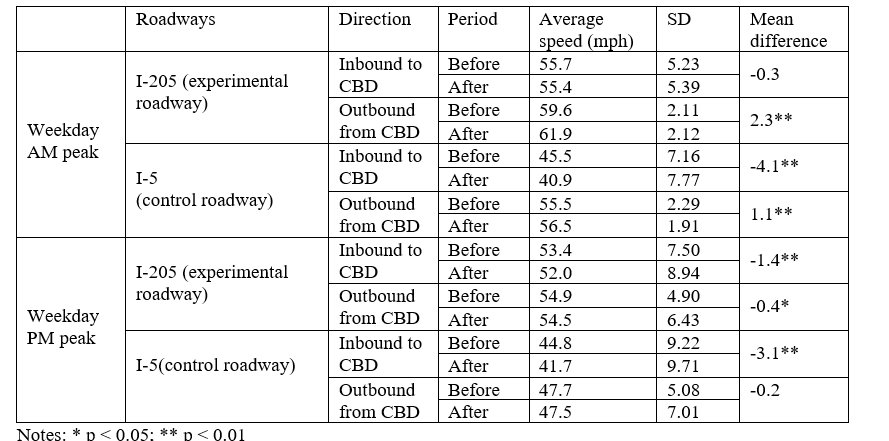

### 4.2.3 DID base regression

A one-group pre-treatment/post-treatment comparison of the experimental roadway segment is weak because it lacks a control group and it may be in doubt to attribute the changes to the operation of the Orange Line. To circumvent this weakness, this study, therefore, utilized a difference-in-difference (DID) approach. The following table shows the results of the DID regression model. Of the four models, compared to the control roadway segment and pre-operation period, the coefficients of DID estimators indicate a significant relative increase in the speed of the experimental roadway in all cases, indicating that the Orange Line has a relief effect on traffic congestion on the experimental segment. The size of impacts is different across the AM/PM peak periods and inbound to/outbound from CBD directions.

```
##
## Orange Line speed base models
## ======================================================================================================
##                                                          Dependent variable:
##                                -----------------------------------------------------------------------
##                                                             Travel Speed
##                                   AM Outbound       AM Inbound        PM Outbound       PM Inbound
##                                       (1)               (2)               (3)               (4)
## ------------------------------------------------------------------------------------------------------
## Time Period (after = 1)            -0.257***         -0.748***         -2.130***         -1.490***
##                                     (0.077)           (0.180)           (0.108)           (0.083)
##
## Group (experimental group = 1)     10.300***         6.690***          9.090***          12.000***
##                                     (0.077)           (0.180)           (0.108)           (0.083)
##
## Time Period × Group                2.350***          1.500***          1.350***          2.070***
##                                     (0.109)           (0.255)           (0.152)           (0.117)
##
## Constant                           23.200***         19.500***         19.700***         21.800***
##                                     (0.055)           (0.127)           (0.076)           (0.058)
##
## ------------------------------------------------------------------------------------------------------
## Observations                         3,129             3,130             3,128             3,128
## R2                                   0.935             0.524             0.844             0.941
## Adjusted R2                          0.935             0.523             0.843             0.941
## Residual Std. Error            1.530 (df = 3125) 3.570 (df = 3126) 2.130 (df = 3124) 1.630 (df = 3124)
## ======================================================================================================
## Note:                                                                      *p<0.1; **p<0.05; ***p<0.01
```

```
##
## GL Route Travel Speed 09/12/2004-09/12/2014 & I-84 as the experimental corridor
## ======================================================================================================
##                                                          Dependent variable:
##                                -----------------------------------------------------------------------
##                                                             Travel Speed
##                                   AM Inbound        PM Inbound        AM Outbound       PM Outbound
##                                       (1)               (2)               (3)               (4)
## ------------------------------------------------------------------------------------------------------
## Time Period (after = 1)            -4.600***         -3.100***         0.931***           -0.279
##                                     (0.470)           (0.647)           (0.147)           (0.462)
##
## Group (experimental group = 1)     10.200***         8.550***          4.110***          7.190***
##                                     (0.607)           (0.823)           (0.188)           (0.584)
##
## Time Period × Group                4.340***           1.730*           1.280***           -0.119
##                                     (0.668)           (0.906)           (0.205)           (0.640)
##
## Constant                           45.500***         44.800***         55.500***         47.700***
##                                     (0.431)           (0.592)           (0.135)           (0.424)
##
## ------------------------------------------------------------------------------------------------------
## Observations                         2,805             2,841             2,895             2,925
## R2                                   0.523             0.235             0.627             0.232
## Adjusted R2                          0.522             0.234             0.627             0.231
## Residual Std. Error            6.700 (df = 2801) 9.190 (df = 2837) 2.050 (df = 2891) 6.470 (df = 2921)
## ======================================================================================================
## Note:                                                                      *p<0.1; **p<0.05; ***p<0.01
```

Using the results of the DID models, the following figure displays the changes in average peak period travel speed from before to after (Time = 1) the operation of the Orange Line for both the experimental and control roadway segments by directions and peak periods. The “counterfactual” line shows what might have happened in the absence of the operation of the Orange Line, assuming the change in travel speed on the experimental roadway segment would be the same as the change in travel speed on the control roadway segment. As shown in Figure 4.9, travel speed on the experimental roadway segment for after period is higher than that in the counterfactual scenario for after period. This reveals that the operation of the Orange Line has had a relief effect on travel speed on the experimental roadway segment.

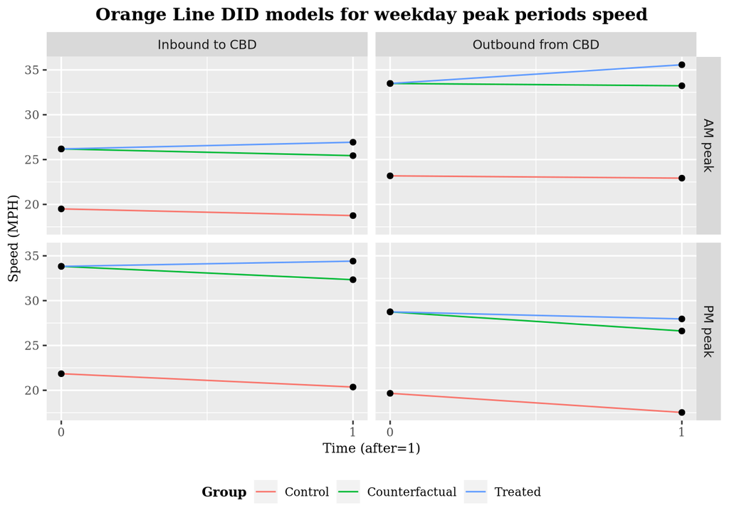

Figure 4.9: Orange Line DID base models for weekday peak periods speed

Figure 4.10

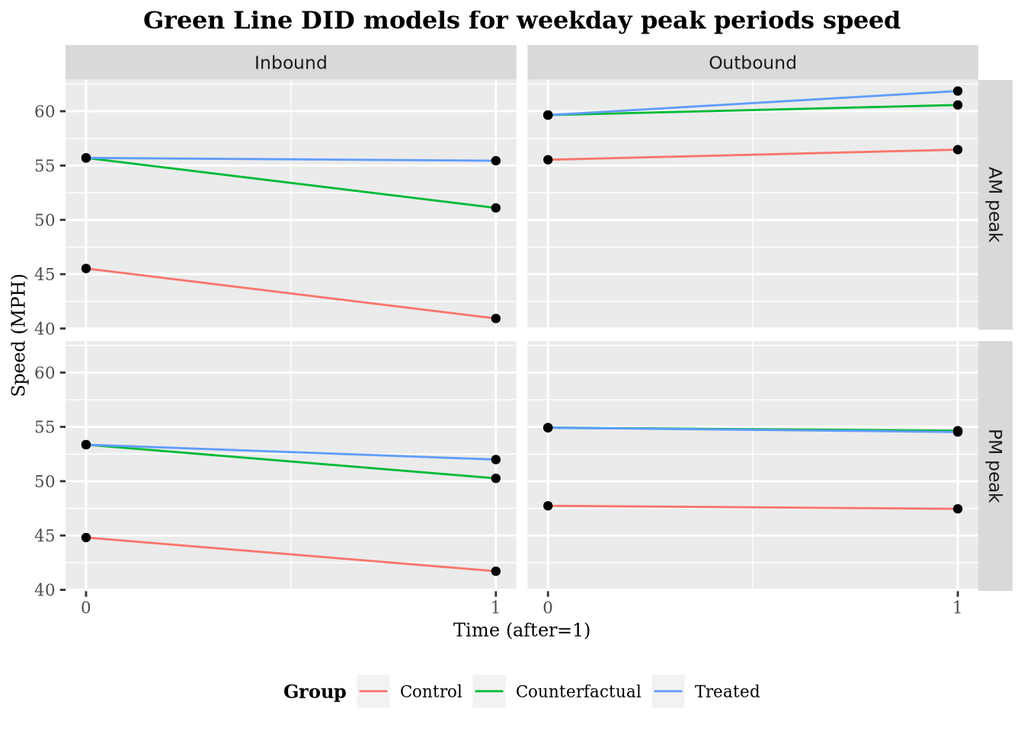

Figure 4.10: Green Line DID base models for weekday peak periods speed

### 4.2.4 DID Multiple time periods models

To investigate the changes in peak periods travel speed over time, DID regression models with multiple time periods are estimated. I creat year dummies for all years (1st year: 09/12/2015 - 09/11/2016; 2nd year: 09/12/2016 - 09/11/2017; 3rd year: 09/12/2017 - 09/11/2018). The following table shows the results of the DID regression models. Of the four models, the coefficients of DID estimators indicate significant relative increase in the speed of the experiment roadway in most cases. Only the DID estimator for the first year PM peak outbound from CBD is negative, but it is not statistically significant. The results reveal that the Orange Line has had a positive impact on average peak periods travel speed on SE McLoughlin Blvd.

```
##
## Orange Line speed DID with multiple time priods
## =====================================================================================================
##                                                         Dependent variable:
##                               -----------------------------------------------------------------------
##                                                            Travel Speed
##                                  AM Outbound       AM Inbound        PM Outbound       PM Inbound
##                                      (1)               (2)               (3)               (4)
## -----------------------------------------------------------------------------------------------------
## ec_groupexperimental              10.300***         6.690***          9.090***          12.000***
##                                    (0.075)           (0.179)           (0.105)           (0.081)
##
## year_1st                          -0.315***         -0.558**          -1.580***         -1.490***
##                                    (0.106)           (0.254)           (0.149)           (0.114)
##
## year_2nd                          -0.380***         -1.380***         -2.830***         -1.710***
##                                    (0.105)           (0.254)           (0.148)           (0.114)
##
## year_3rd                           -0.076            -0.307           -1.990***         -1.260***
##                                    (0.105)           (0.254)           (0.148)           (0.114)
##
## ec_groupexperimental:year_1st     1.320***           0.622*            -0.059           1.200***
##                                    (0.149)           (0.359)           (0.210)           (0.162)
##
## ec_groupexperimental:year_2nd     2.710***          1.970***          1.760***          2.460***
##                                    (0.149)           (0.359)           (0.210)           (0.162)
##
## ec_groupexperimental:year_3rd     3.000***          1.900***          2.340***          2.550***
##                                    (0.149)           (0.359)           (0.210)           (0.162)
##
## Constant                          23.200***         19.500***         19.700***         21.800***
##                                    (0.053)           (0.127)           (0.074)           (0.057)
##
## -----------------------------------------------------------------------------------------------------
## Observations                        3,129             3,130             3,128             3,128
## R2                                  0.939             0.529             0.852             0.944
## Adjusted R2                         0.939             0.528             0.852             0.944
## Residual Std. Error           1.470 (df = 3121) 3.550 (df = 3122) 2.080 (df = 3120) 1.600 (df = 3120)
## =====================================================================================================
## Note:                                                                     *p<0.1; **p<0.05; ***p<0.01
```

```
##
## GL Route Travel Speed 09/12/2004-09/12/2014 & I-84 as the experimental corridor
## ===========================================================================================
##                                               Dependent variable:
##                     -----------------------------------------------------------------------
##                                                  Travel Speed
##                        AM Inbound        PM Inbound        AM Outbound       PM Outbound
##                            (1)               (2)               (3)               (4)
## -------------------------------------------------------------------------------------------
## Group                   10.200***         8.550***          4.110***          7.190***
##                          (0.589)           (0.807)           (0.171)           (0.573)
##
## year_1st                -1.250**           -0.580           1.400***           -0.093
##                          (0.583)           (0.808)           (0.170)           (0.574)
##
## year_2nd                -5.240***          -0.323           1.190***          2.350***
##                          (0.582)           (0.811)           (0.169)           (0.583)
##
## year_3rd                -5.470***         -4.830***         0.794***           -1.110*
##                          (0.582)           (0.806)           (0.170)           (0.571)
##
## year_4th                -4.620***         -3.670***         0.887***          -1.680***
##                          (0.586)           (0.820)           (0.171)           (0.577)
##
## year_5th                -6.640***         -6.400***          0.311*            -0.762
##                          (0.599)           (0.831)           (0.175)           (0.587)
##
## Group:year_1st          2.710***            0.142           -0.799***          -0.009
##                          (0.823)           (1.130)           (0.238)           (0.801)
##
## Group:year_2nd          5.390***            0.502            -0.023           -2.880***
##                          (0.822)           (1.140)           (0.237)           (0.807)
##
## Group:year_3rd          6.110***          4.070***          3.370***          3.120***
##                          (0.825)           (1.140)           (0.240)           (0.806)
##
## Group:year_4th          2.390***            0.208           1.880***            0.876
##                          (0.842)           (1.150)           (0.242)           (0.817)
##
## Group:year_5th           2.040*             2.060           2.300***          -2.120**
##                          (1.040)           (1.370)           (0.247)           (0.830)
##
## Constant                45.500***         44.800***         55.500***         47.700***
##                          (0.418)           (0.581)           (0.123)           (0.415)
##
## -------------------------------------------------------------------------------------------
## Observations              2,805             2,841             2,895             2,925
## R2                        0.551             0.266             0.692             0.264
## Adjusted R2               0.549             0.264             0.691             0.261
## Residual Std. Error 6.510 (df = 2793) 9.010 (df = 2829) 1.860 (df = 2883) 6.340 (df = 2913)
## ===========================================================================================
## Note:                                                           *p<0.1; **p<0.05; ***p<0.01
```

Using the results of DID models with multiple time periods, Figure 4.11 shows predicted average weekday peak periods speed over time. The dashed horizontal lines indicate the average treated impacts of corresponding cases. The line plot reveals the nonlinear effect of the Orange Line on traffic. Overall, the size of the effects increased over time. The size of yearly effects is different for AM/PM peak periods and inbound to and outbound from CBD directions.

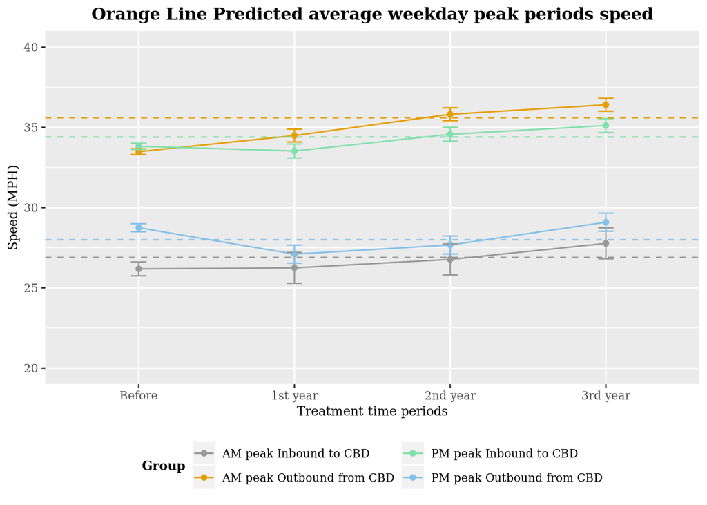

Figure 4.11: Orange Line DID multiple time periods models for weekday peak periods speed

Figure 4.12

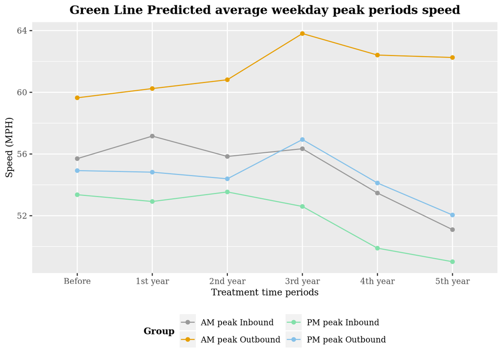

Figure 4.12: Green Line DID multiple time periods models for weekday peak periods speed